# Turning Data into Infomation

b06208001 龔泓愷

2018年9月22日

#### 2.8

1. 2391
2. People aged 65 or older
3. ‘People attended a religious service once a week and prayed or studied the Bible’ & ‘Less likely to have high blood plessure’
4. Sample Data, because the study was hard to follow all the population.

#### 2.20

For this situation, the explanatory variable is ‘Smokers/Non-smokers’ and the response variable is ‘Development of dementia’.  
The explanatory variable here should be described as categorical.  
On the other hand, the response variable is quantitative here.

#### 2.30

1. 1700/2470 * 100%

```r
1700/2470 * 100
```

```
## [1] 68.82591
```

2. 1056/1700 * 100%

```r
1056/1700 * 100
```

```
## [1] 62.11765
```

3. 300/657 * 100%

```r
300/657 * 100
```

```
## [1] 45.6621
```

4. 41/113 * 100%

```r
41/113 * 100
```

```
## [1] 36.28319
```

#### 2.32

```r
Description <- c('Under 20', '20-24', '25-29', '30-34', '35 and Over')
Percentage <- c(20.9, 30.6, 24.7, 15.7, 8.1)
Q232 <- data.frame(Description, Percentage)
Q232
```

```
##   Description Percentage
## 1    Under 20       20.9
## 2       20-24       30.6
## 3       25-29       24.7
## 4       30-34       15.7
## 5 35 and Over        8.1
```

1. Bar Plot

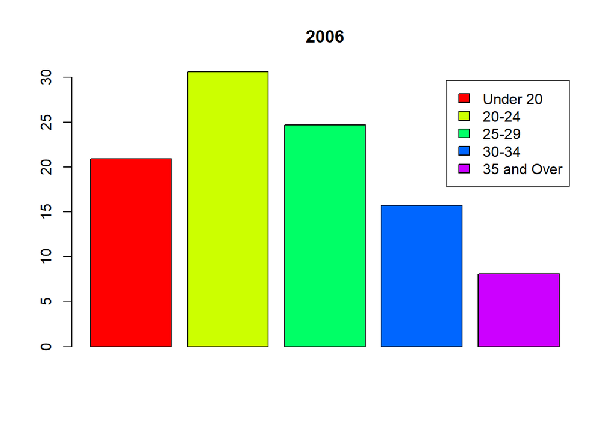

```r
barplot(Percentage, main = '2006', col = rainbow(5), legend = Description)
library(ggplot2)
```

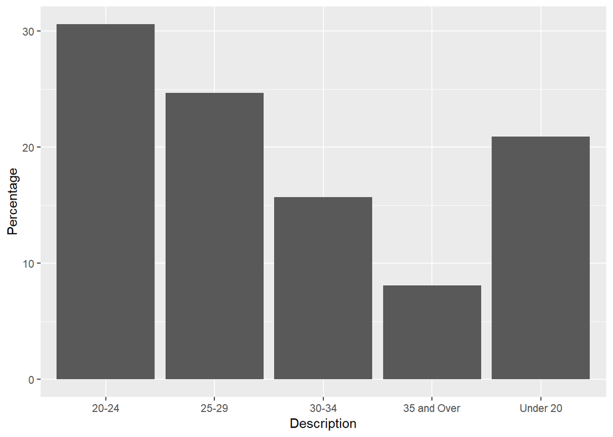

```r
ggplot(Q232, aes(x = Description, y = Percentage)) +
  geom_col()
```

2. Pie Chart

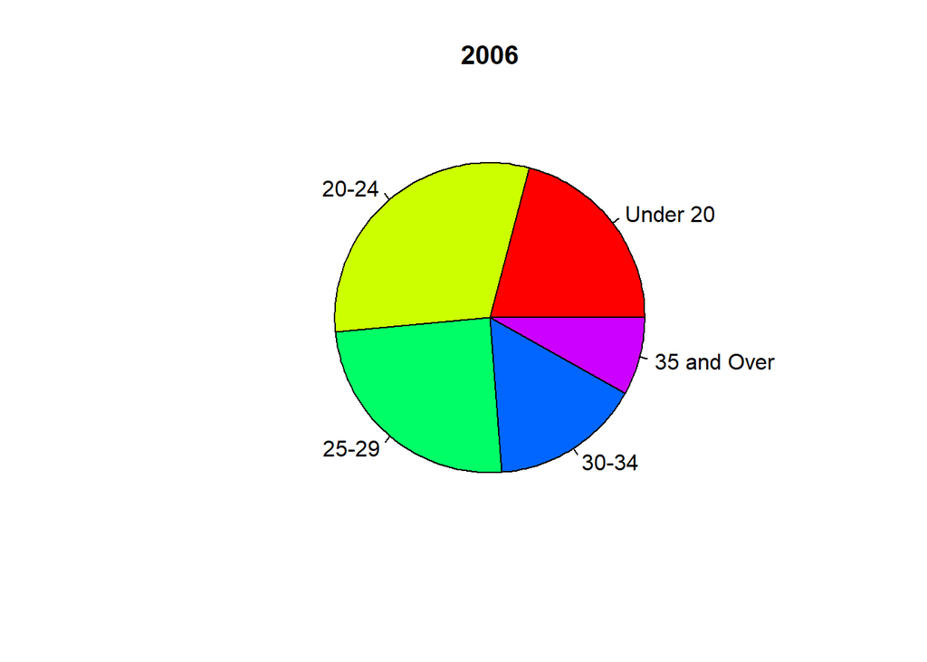

```r
pie(Percentage, main = '2006', col = rainbow(5), labels = Description)
```

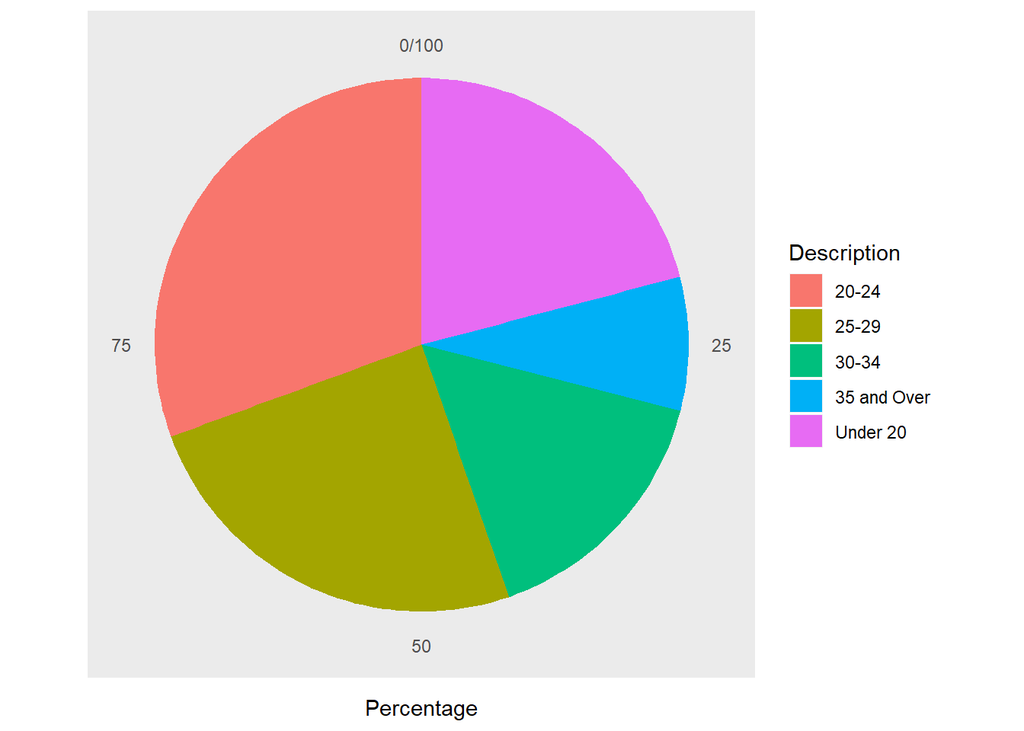

```r
ggplot(Q232, aes(x = 1, y = Percentage, fill = Description)) +
  geom_col() +
  coord_polar(theta = 'y') +
  theme(axis.title.y = element_blank(),
        line = element_blank(),
        axis.text.y = element_blank())
```

3. Explain  
   From my point of view, when it comes to deciphering a pie chart, people will use angle, area or arc length which are all mediocre encoding elements, so none of them are really ideal and it would be much more informative when we use bar plot.

#### 2.46

```r
musiccds <- c(220,20,50,450,300,30,20,50,200,35,25,50,250,100,0,100,20,13,200,2,125,150,90,60)
```

1. Stem-and-leaf plot

```r
stem(musiccds)
```

```
##
##   The decimal point is 2 digit(s) to the right of the |
##
##   0 | 00122233455569
##   1 | 0035
##   2 | 0025
##   3 | 0
##   4 | 5
```

2. Histogram

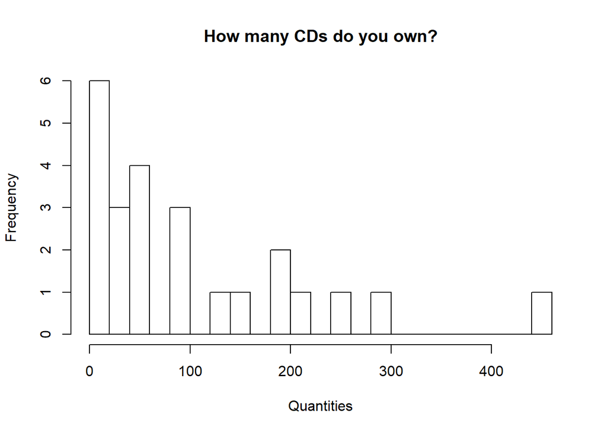

```r
hist(musiccds, breaks = 20, main = 'How many CDs do you own?', xlab = 'Quantities')
```

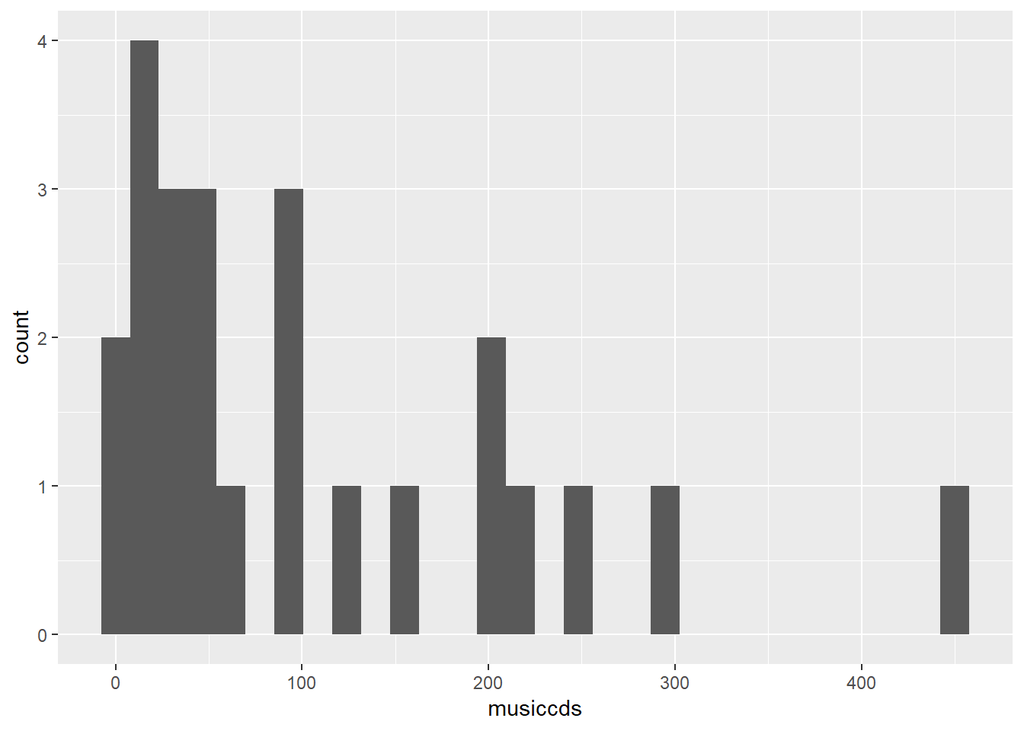

```r
ggplot(as.data.frame(musiccds), aes(x = musiccds)) +
  geom_histogram()
```

3. Characterize  
   According to the histogram, the shape of data is “right-skewed”.

#### 2.52

```r
ceodata08 <- c(42,47,48,49,49,50,50,50,50,51,51,51,52,54,54,55,55,55,55,56,57,57,57,57,57,58,58,59,59,60,60,60,61,61,62,62,62,62,62,63,63,64,64,64,64,67,67,69,74,78)
d <- density(ceodata08, na.rm=TRUE)
```

1. Histogram

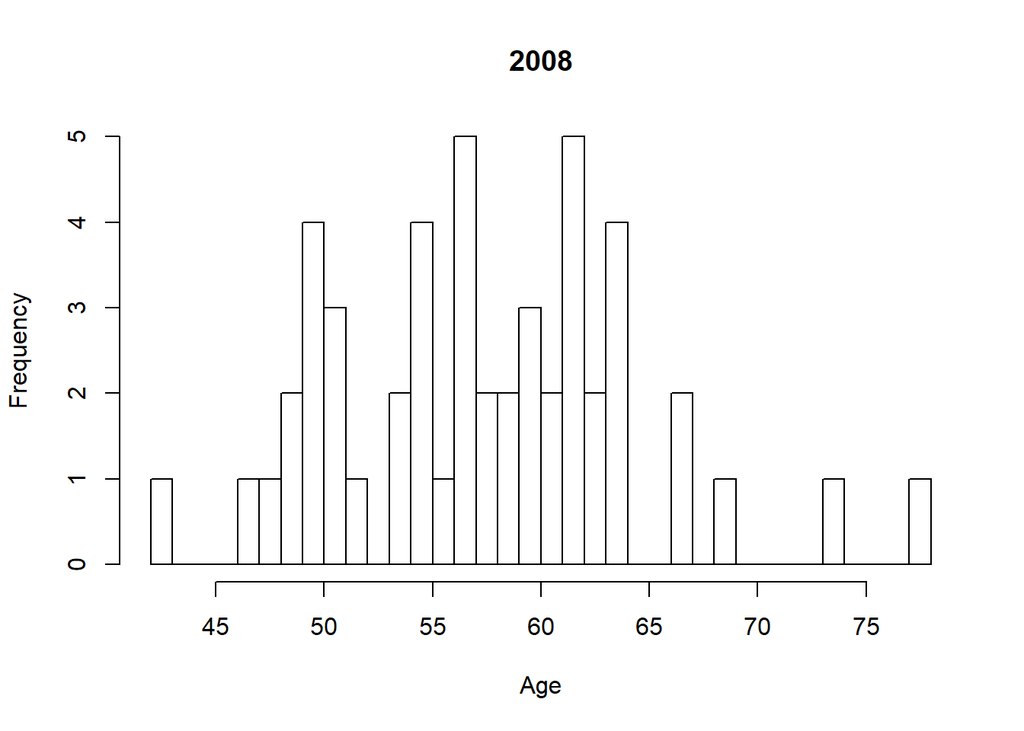

```r
hist(ceodata08, breaks = 30, main = '2008', xlab = 'Age')
```

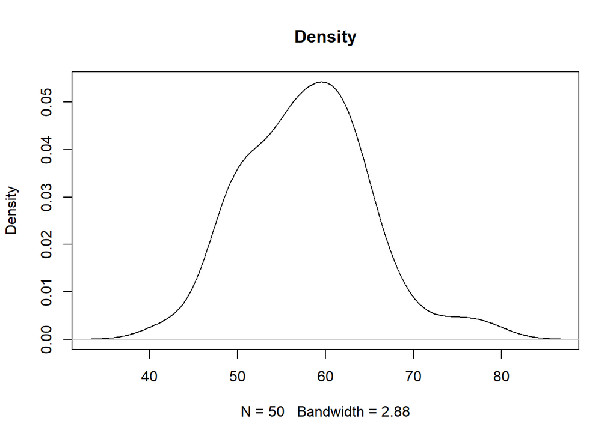

```r
plot(d, main = 'Density')
```

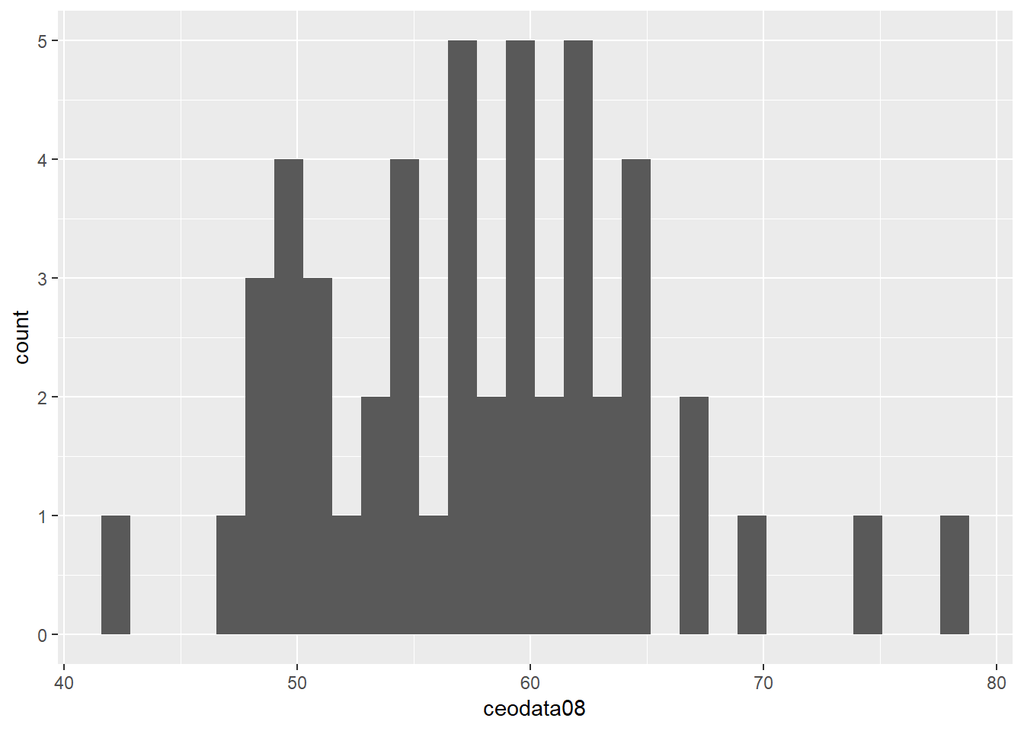

```r
ggplot(as.data.frame(ceodata08), aes(x = ceodata08)) +
  geom_histogram()
```

2. Stem-and-leaf plot

```r
stem(ceodata08)
```

```
##
##   The decimal point is 1 digit(s) to the right of the |
##
##   4 | 2
##   4 | 7899
##   5 | 0000111244
##   5 | 55556777778899
##   6 | 0001122222334444
##   6 | 779
##   7 | 4
##   7 | 8
```

3. Dotplot

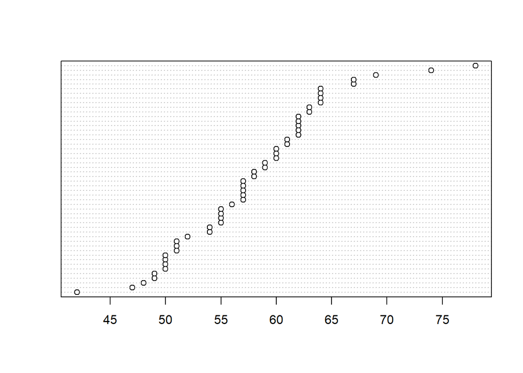

```r
dotchart(ceodata08)
```

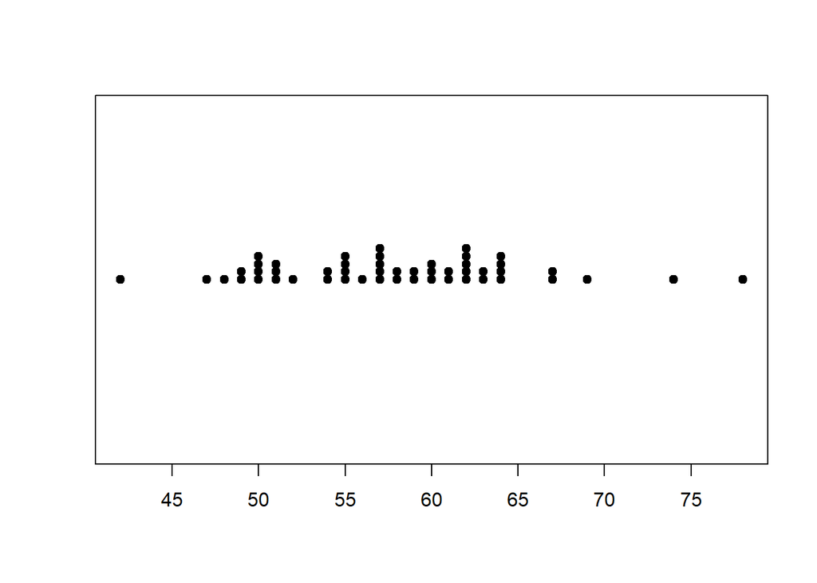

```r
stripchart(ceodata08, method = 'stack', pch = 19)
```

4. Description This data is a little bit ‘Right-skewed’, for the right side is more discrete than the left side.
5. Outliers

```r
IQR <- IQR(ceodata08)
IQR
```

```
## [1] 9.5
```

```r
quantile(ceodata08)
```

```
##   0%  25%  50%  75% 100%
## 42.0 52.5 57.5 62.0 78.0
```

```r
Q1T <- quantile(ceodata08)[2] - 1.5 * IQR
Q3T <- quantile(ceodata08)[4] + 1.5 * IQR
Q1T
```

```
##   25%
## 38.25
```

```r
Q3T
```

```
##   75%
## 76.25
```

In this case, we use 1.5 multiply IQR to determine whether it is an outlier or not.  
As we can see here, the thresholds of outliers are 38.25 & 76.25.  
By definition, the outlier is 78.

6. Explain  
   In my opinion, outliers would be more likely to occur in the salaries of heads of companies in general.  
   According to the magnitude of companies, the salaries differ.  
   Sometimes, we even need to put those data on a log scale to see the trend.

#### 2.66

```r
SBP <- c(110,123,132,150,127,118,102,122)
summary(SBP)
```

```
##    Min. 1st Qu.  Median    Mean 3rd Qu.    Max.
##   102.0   116.0   122.5   123.0   128.2   150.0
```

```r
IQR(SBP)
```

```
## [1] 12.25
```

1. Median：122.5
2. Q1：116.0, Q3：128.2
3. IQR：12.25
4. Outliers

```r
Q1T <- quantile(SBP)[2] - 1.5 * IQR(SBP)
Q3T <- quantile(SBP)[4] + 1.5 * IQR(SBP)
Q1T
```

```
##    25%
## 97.625
```

```r
Q3T
```

```
##     75%
## 146.625
```

There is one outlier：150  
e. Boxplot

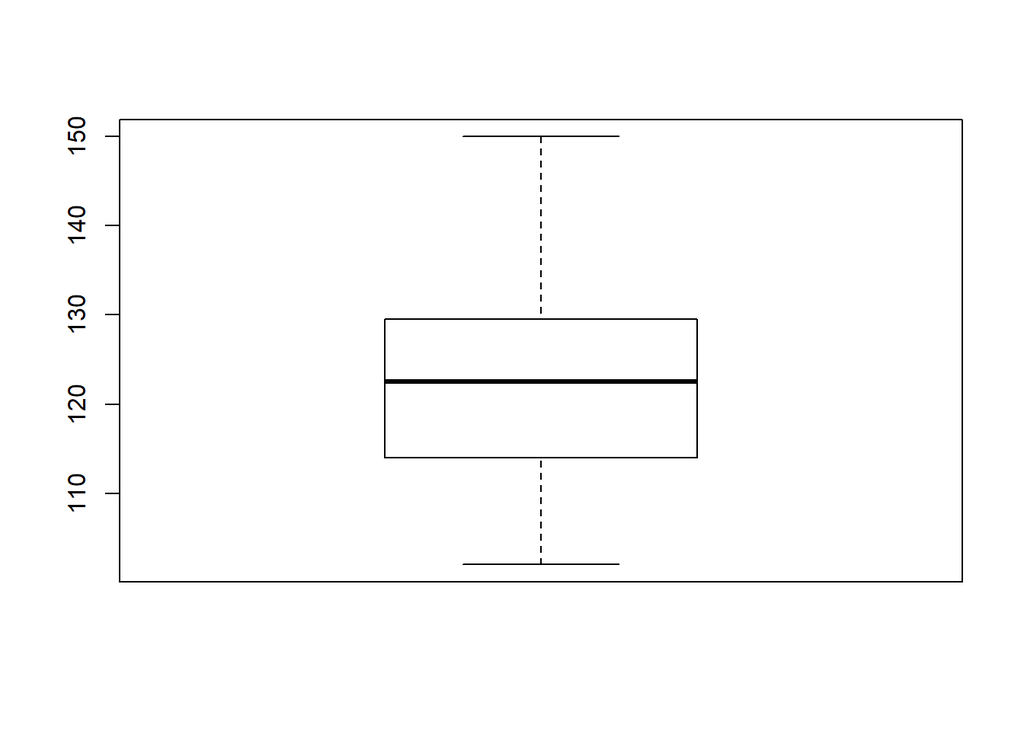

```r
boxplot(SBP)
```

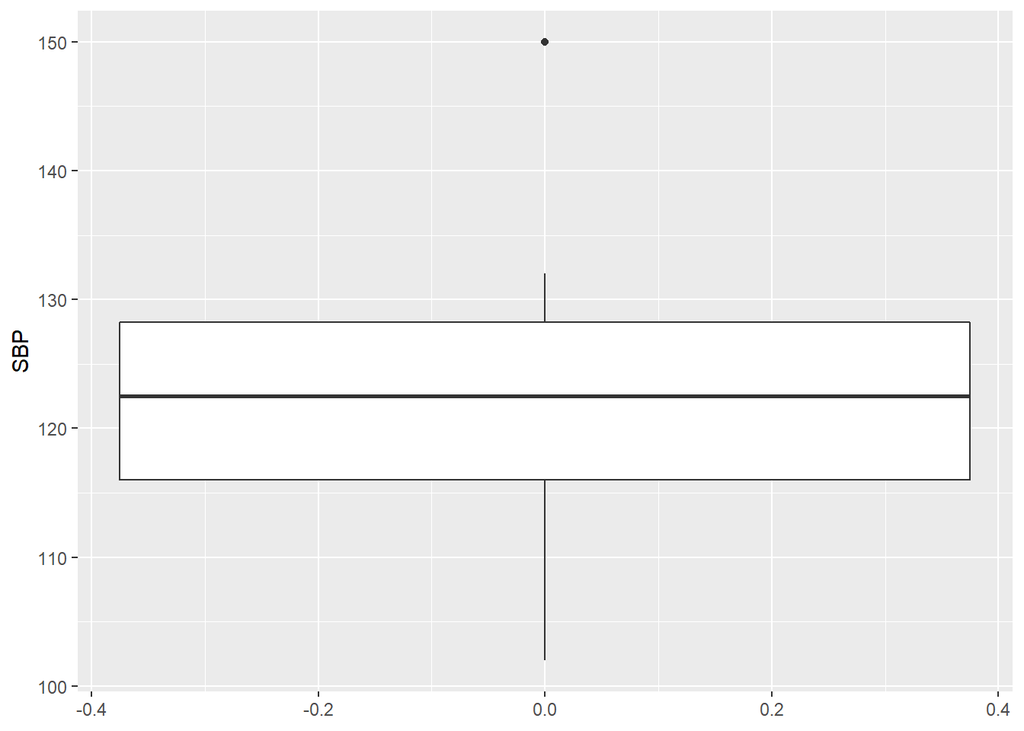

```r
ggplot(as.data.frame(SBP), aes(y = SBP)) +
  geom_boxplot()
```

#### 2.76

```r
G1 <- c(2,30,35,70,100,120,135,150,190,200)
G2 <- c(8,12,16,29,35,40,45,46,95,NA)
G1G2 <- c(G1, G2)
Q276 <- matrix(G1G2, byrow = F, nrow  = 10)
colnames(Q276) <- c('G1', 'G2')
Q276
```

```
##        G1 G2
##  [1,]   2  8
##  [2,]  30 12
##  [3,]  35 16
##  [4,]  70 29
##  [5,] 100 35
##  [6,] 120 40
##  [7,] 135 45
##  [8,] 150 46
##  [9,] 190 95
## [10,] 200 NA
```

1. Five-number-summary of group1

```r
summary(G1)
```

```
##    Min. 1st Qu.  Median    Mean 3rd Qu.    Max.
##    2.00   43.75  110.00  103.20  146.25  200.00
```

```r
IQR(G1)
```

```
## [1] 102.5
```

2. Five-number-summary of group2

```r
summary(G2)
```

```
##    Min. 1st Qu.  Median    Mean 3rd Qu.    Max.    NA's
##    8.00   16.00   35.00   36.22   45.00   95.00       1
```

```r
IQR(G2, na.rm = T)
```

```
## [1] 29
```

3. Range  
   Group1 range = 200 - 2 = 198  
   Group2 range = 95 -8 = 87
4. Boxplot

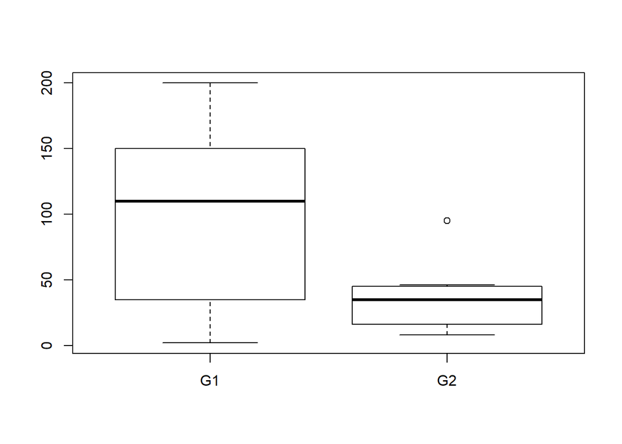

```r
boxplot(Q276)
```

#### 2.96

I would be more satisfied if the standard deviation was 5.  
We can use Z-score to explain.  
If sd was 5, my Z-score would be (80-70)/5 = 2, which means that my performance was much more superior to others and ouststanding.  
If sd was 15, my Z-score would be (80-70)/15 = 0.67, which shows that the score was just slightly beyond average.

#### 2.104

```r
a <- qnorm(0.025, mean = 56, sd = 2)
b <- qnorm(0.975, mean = 56, sd = 2)
c <- qnorm(0.84, mean = 56, sd = 2)
a
```

```
## [1] 52.08007
```

```r
b
```

```
## [1] 59.91993
```

```r
c
```

```
## [1] 57.98892
```

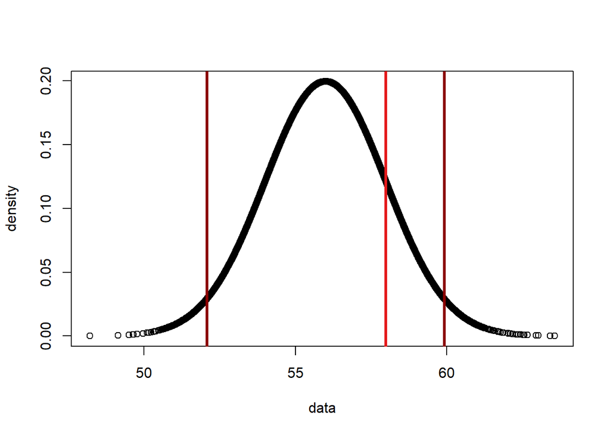

```r
# Simulate some random normally distributed data
set.seed(11225)
data <- rnorm(10000, mean = 56, sd = 2)

# Calculate the density of data and store it in the variable density
density <- dnorm(data, mean = 56, sd = 2)

plot(data, density)
abline(v = a, lwd = 3, col = 'darkred')
abline(v = b, lwd = 3, col = 'darkred')
abline(v = c, lwd = 3, col = '#E41A1C')
```

#### Function Practice

```r
setwd("D:/GitHub/107-Statistics/Lab2")
Student = read.csv('Student.csv')
MyOutlierDetect <- function(x, y){
  Q1T <- quantile(x, na.rm = T)[2] - 1.5 * IQR(x, na.rm = T)
  Q3T <- quantile(x, na.rm = T)[4] + 1.5 * IQR(x, na.rm = T)
  if(y < Q1T | y > Q3T){
    print('YES')
  }else{
    print('NO')
  }
}
GPA = Student$GPA
MyOutlierDetect(GPA, 1.5)
```

```
## [1] "YES"
```